# Figures 5A, 5C, and 5D

# 8 Data overview

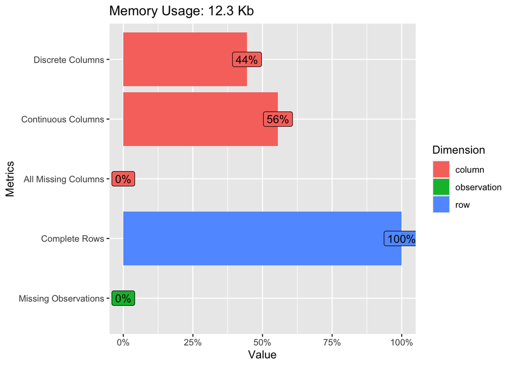

```r
plot_intro(analysis_data)
```

# 9 Analysis configuration

`predictor_config` defines each variable, its covariates, x-axis unit, figure label, and the exact caption formula displayed in each plot. `outcome_config` defines the two imaging outcomes.

```r
predictor_config <- list(

  Age = list(
    variable        = "Age",
    label           = "Age",
    covariates      = c("Sex", "Arm"),
    unit            = "years",
    caption_formula = "LME: outcome ~ Visit * Age + Sex + Arm + (1|ID1)"
  ),

  BMI_0 = list(
    variable        = "BMI_0",
    label           = "W0 BMI",
    covariates      = c("Age", "Sex", "Arm"),
    unit            = "kg/m2",
    caption_formula = "LME: outcome ~ Visit * BMI_0 + Age + Sex + Arm + (1|ID1)"
  ),

  MGIT_0 = list(
    variable        = "MGIT_0",
    label           = "W0 MGIT Mtb burden",
    covariates      = c("Age", "Sex", "Arm"),
    unit            = "",
    caption_formula = "LME: outcome ~ Visit * MGIT_0 + Age + Sex + Arm + (1|ID1)"
  )
)

outcome_config <- list(

  CAVTOT = list(
    outcome      = "CAVTOT",
    label        = "Total cavity volume (log10 mL)",
    min_obs      = 10,
    min_subjects = 5
  ),

  TLG = list(
    outcome      = "TLG",
    label        = "Total lesion glycolysis (log10 mL)",
    min_obs      = 10,
    min_subjects = 5
  )
)

cat("predictor_config entries:", paste(names(predictor_config), collapse = ", "), "\n")
```

```
predictor_config entries: Age, BMI_0, MGIT_0
```

```r
cat("outcome_config entries:",   paste(names(outcome_config),   collapse = ", "), "\n")
```

```
outcome_config entries: CAVTOT, TLG
```

# 10 Visit colours

```r
visit_colors <- c("W0" = "#000000", "W4" = "orange", "W16" = "#00CCFF", "W24" = "purple")
```

# 11 LME screening function

`screen_lme`: fits `outcome ~ Visit * Predictor_Value + covariates + (1|ID1)` for one predictor and one outcome. Returns Wald chi-square p-values for the Visit main effect, predictor main effect, and interaction. Returns NULL if data are insufficient.

```r
screen_lme <- function(data, predictor_name, outcome,
                       covariates   = NULL,
                       min_obs      = 10,
                       min_subjects = 5) {

  keep_cols <- unique(c("ID1", "Visit", outcome, predictor_name, covariates))

  dat <- data %>%
    select(all_of(keep_cols)) %>%
    filter(!is.na(.data[[outcome]]),
           !is.na(.data[[predictor_name]])) %>%
    rename(Predictor_Value = all_of(predictor_name)) %>%
    mutate(
      Predictor_Value = if (is.factor(Predictor_Value)) {
                          as.numeric(Predictor_Value) - 1
                        } else {
                          as.numeric(Predictor_Value)
                        },
      ID1   = as.factor(ID1),
      Visit = factor(Visit, levels = c("W0", "W4", "W16", "W24"))
    )

  if (nrow(dat) < min_obs || n_distinct(dat$ID1) < min_subjects) return(NULL)

  covariate_terms <- if (!is.null(covariates)) paste(covariates, collapse = " + ") else NULL
  formula_str     <- paste(
    outcome, "~ Visit * Predictor_Value",
    if (!is.null(covariate_terms)) paste("+", covariate_terms),
    "+ (1|ID1)"
  )

  tryCatch({
    model     <- lmer(as.formula(formula_str), data = dat, REML = FALSE)
    anova_res <- Anova(model, type = 3)

    data.frame(
      Predictor     = predictor_name,
      Visit_p       = anova_res["Visit",                 "Pr(>Chisq)"],
      Predictor_p   = anova_res["Predictor_Value",       "Pr(>Chisq)"],
      Interaction_p = anova_res["Visit:Predictor_Value", "Pr(>Chisq)"],
      N_obs         = nrow(dat),
      N_subjects    = n_distinct(dat$ID1),
      stringsAsFactors = FALSE
    )
  }, error = function(e) {
    message("LME failed for ", predictor_name, ": ", e$message)
    NULL
  })
}
```

# 12 P-value formatting helper

```r
format_p <- function(p) {
  stars <- if (p < 0.001) "***" else if (p < 0.01) "**" else if (p < 0.05) "*" else ""
  label <- if (p < 0.001) "p < 0.001" else sprintf("p = %.3f", p)
  paste0(label, stars)
}
```

# 13 LME plot function

`plot_lme`: fits the same model as `screen_lme` and generates a scatter plot with LME-predicted regression lines per visit and 95% confidence bands from emmeans. Raw p-values with significance stars are shown in the subtitle. Regression equations are annotated in the top right corner. The caption formula is taken from `predictor_config` and displayed exactly as specified.

```r
plot_lme <- function(data, predictor_name, predictor_label, predictor_unit,
                     outcome, outcome_label, caption_formula,
                     visit_colors, covariates = NULL, save_path = NULL) {

  keep_cols <- unique(c("ID1", "Visit", outcome, predictor_name, covariates))

  dat <- data %>%
    select(all_of(keep_cols)) %>%
    filter(!is.na(.data[[outcome]]),
           !is.na(.data[[predictor_name]])) %>%
    rename(Predictor_Value = all_of(predictor_name)) %>%
    mutate(
      Predictor_Value = if (is.factor(Predictor_Value)) {
                          as.numeric(Predictor_Value) - 1
                        } else {
                          as.numeric(Predictor_Value)
                        },
      ID1   = as.factor(ID1),
      Visit = factor(Visit, levels = c("W0", "W4", "W16", "W24"))
    )

  if (nrow(dat) < 10 || n_distinct(dat$ID1) < 5) return(invisible(NULL))

  covariate_terms <- if (!is.null(covariates)) paste(covariates, collapse = " + ") else NULL
  formula_str     <- paste(
    outcome, "~ Visit * Predictor_Value",
    if (!is.null(covariate_terms)) paste("+", covariate_terms),
    "+ (1|ID1)"
  )

  model <- tryCatch(
    lmer(as.formula(formula_str), data = dat, REML = FALSE),
    error = function(e) NULL
  )

  if (is.null(model)) return(invisible(NULL))

  anova_res     <- Anova(model, type = 3)
  visit_p       <- anova_res["Visit",                 "Pr(>Chisq)"]
  predictor_p   <- anova_res["Predictor_Value",       "Pr(>Chisq)"]
  interaction_p <- anova_res["Visit:Predictor_Value", "Pr(>Chisq)"]

  pred_seq <- seq(
    min(dat$Predictor_Value, na.rm = TRUE),
    max(dat$Predictor_Value, na.rm = TRUE),
    length.out = 50
  )

  pred <- as.data.frame(
    emmeans(model, ~ Visit * Predictor_Value,
            at = list(Predictor_Value = pred_seq))
  )

  coefs         <- fixef(model)
  intercept_w0  <- coefs["(Intercept)"]
  slope_w0      <- coefs["Predictor_Value"]

  intercept_w4  <- intercept_w0 +
    ifelse("VisitW4" %in% names(coefs), coefs["VisitW4"], 0)
  slope_w4      <- slope_w0 +
    ifelse("VisitW4:Predictor_Value" %in% names(coefs),
           coefs["VisitW4:Predictor_Value"], 0)

  intercept_w16 <- intercept_w0 +
    ifelse("VisitW16" %in% names(coefs), coefs["VisitW16"], 0)
  slope_w16     <- slope_w0 +
    ifelse("VisitW16:Predictor_Value" %in% names(coefs),
           coefs["VisitW16:Predictor_Value"], 0)

  intercept_w24 <- intercept_w0 +
    ifelse("VisitW24" %in% names(coefs), coefs["VisitW24"], 0)
  slope_w24     <- slope_w0 +
    ifelse("VisitW24:Predictor_Value" %in% names(coefs),
           coefs["VisitW24:Predictor_Value"], 0)

  visits_present <- levels(droplevels(dat$Visit))

  eq_lines <- c()
  if ("W0"  %in% visits_present)
    eq_lines <- c(eq_lines, sprintf("W0:  y = %.3fx %s %.3f",
      slope_w0,  ifelse(intercept_w0  >= 0, "+", "-"), abs(intercept_w0)))
  if ("W4"  %in% visits_present)
    eq_lines <- c(eq_lines, sprintf("W4:  y = %.3fx %s %.3f",
      slope_w4,  ifelse(intercept_w4  >= 0, "+", "-"), abs(intercept_w4)))
  if ("W16" %in% visits_present)
    eq_lines <- c(eq_lines, sprintf("W16: y = %.3fx %s %.3f",
      slope_w16, ifelse(intercept_w16 >= 0, "+", "-"), abs(intercept_w16)))
  if ("W24" %in% visits_present)
    eq_lines <- c(eq_lines, sprintf("W24: y = %.3fx %s %.3f",
      slope_w24, ifelse(intercept_w24 >= 0, "+", "-"), abs(intercept_w24)))

  eq_label <- paste(eq_lines, collapse = "\n")

  p <- ggplot() +
    geom_ribbon(
      data = pred,
      aes(x = Predictor_Value, ymin = lower.CL, ymax = upper.CL, fill = Visit),
      alpha = 0.2
    ) +
    geom_line(
      data = pred,
      aes(x = Predictor_Value, y = emmean, color = Visit),
      linewidth = 1.5
    ) +
    geom_point(
      data = dat,
      aes(x = Predictor_Value, y = .data[[outcome]], color = Visit),
      alpha = 0.6, size = 2.5
    ) +
    annotate(
      "text",
      x = Inf, y = Inf, label = eq_label,
      hjust = 1.05, vjust = 1.5, size = 4.2,
      fontface = "italic", color = "black"
    ) +
    scale_color_manual(values = visit_colors, name = "Visit") +
    scale_fill_manual(values  = visit_colors, name = "Visit") +
    labs(
      title    = predictor_label,
      subtitle = paste0(
        "Visit: ",       format_p(visit_p),     "  |  ",
        "Predictor: ",   format_p(predictor_p), "  |  ",
        "Interaction: ", format_p(interaction_p)
      ),
      x       = paste0(predictor_label, " (", predictor_unit, ")"),
      y       = outcome_label,
      caption = caption_formula
    ) +
    theme_classic(base_size = 12) +
    theme(
      legend.position = "top",
      plot.title      = element_text(face = "bold"),
      plot.subtitle   = element_text(size = 12, color = "black"),
      panel.grid.major    = element_line(color = "grey85", linewidth = 0.4),
      panel.grid.minor    = element_line(color = "grey92", linewidth = 0.2)
    )

  print(p)

  if (!is.null(save_path)) {
    ggsave(
      file.path(save_path,
                paste0(predictor_name, "_LME_", outcome, ".pdf")),
      plot = p, width = 8, height = 6, units = "in"
    )
  }

  invisible(p)
}
```

# 14 Run all analyses

For each outcome, each predictor is tested independently.

```
Outcome: Total cavity volume (log10 mL)
  Predictors screened: 3
  Significant (p < 0.05): Visit = 2 | Predictor = 1 | Interaction = 1
```

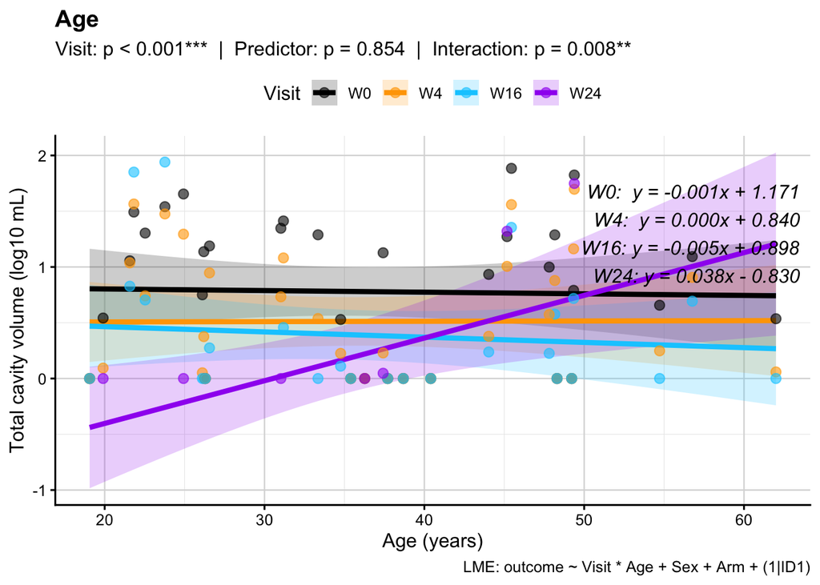

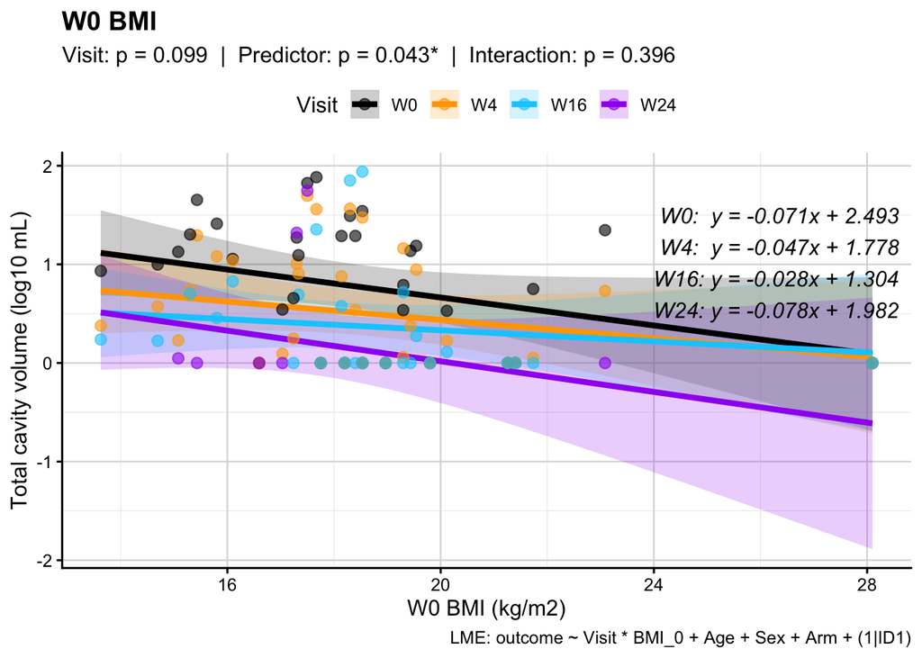

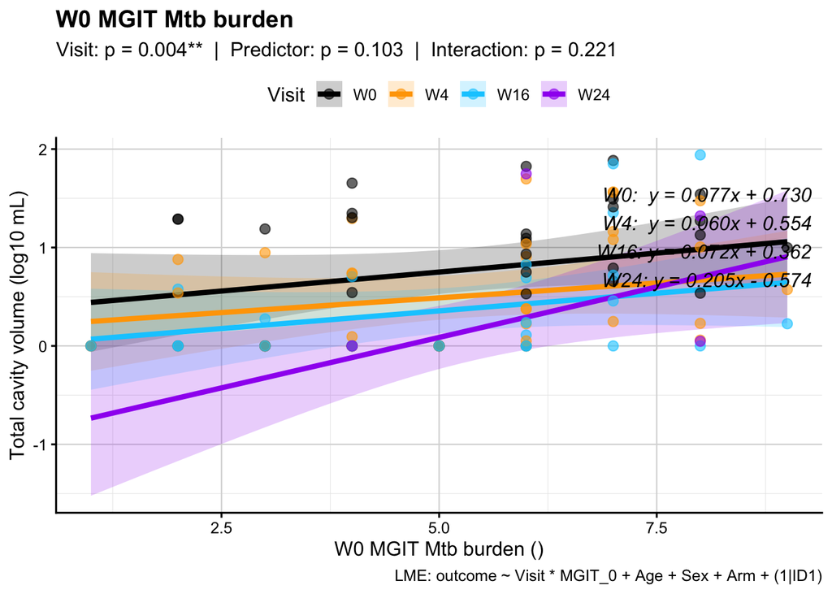

```
Outcome: Total lesion glycolysis (log10 mL)
  Predictors screened: 3
  Significant (p < 0.05): Visit = 2 | Predictor = 0 | Interaction = 2
```

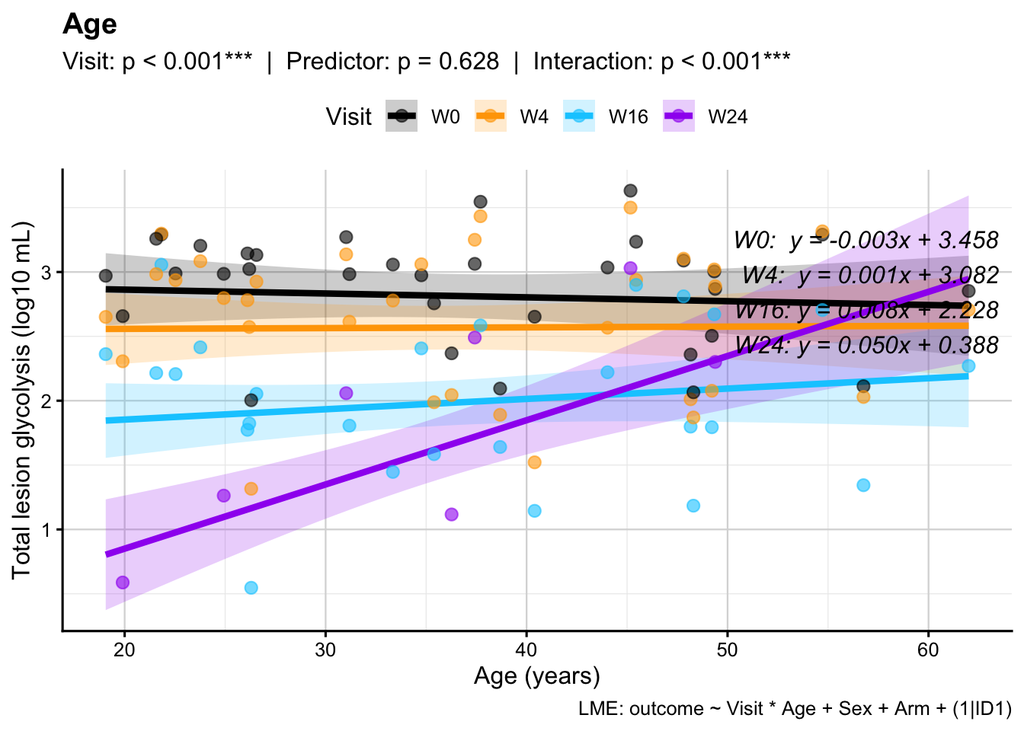

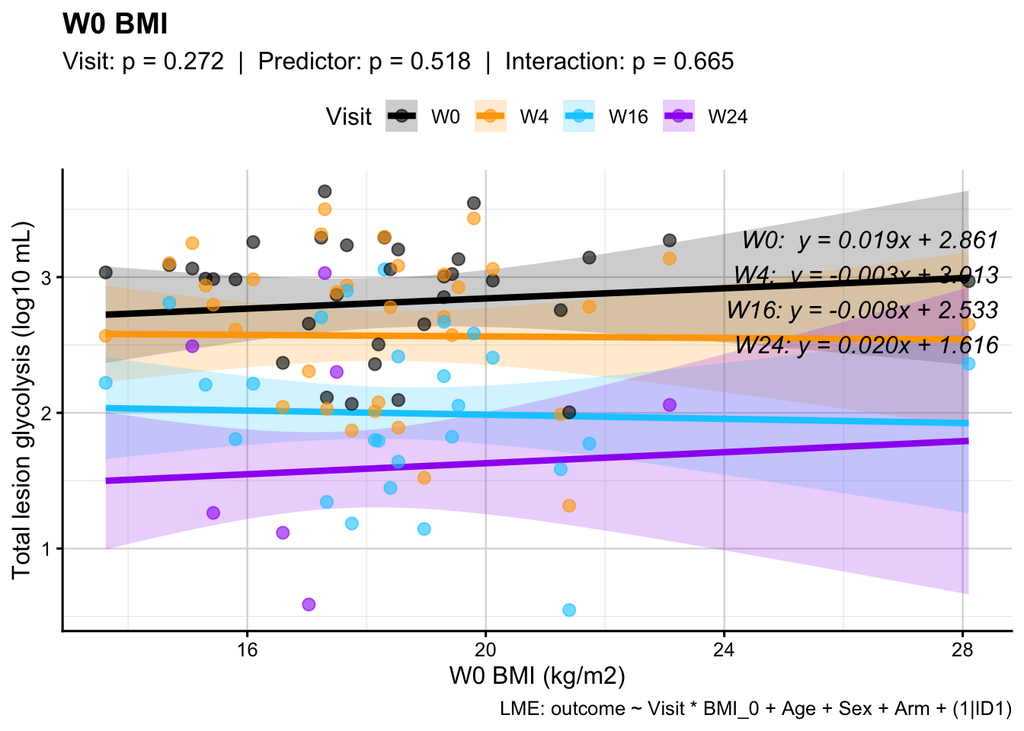

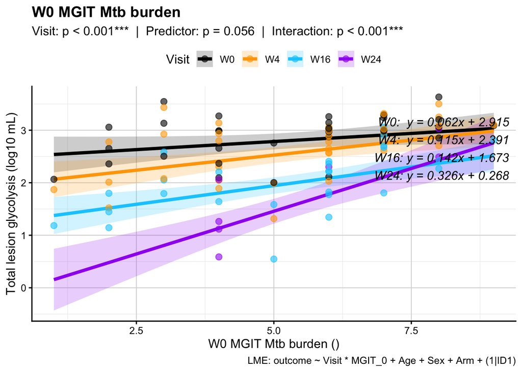

```r
all_analyses <- list()

for (outcome_name in names(outcome_config)) {
  out_cfg <- outcome_config[[outcome_name]]
  out_dir <- file.path(output_main, outcome_name)
  dir.create(out_dir, recursive = TRUE, showWarnings = FALSE)

  cat(sprintf("\nOutcome: %s\n", out_cfg$label))

  screening_results <- bind_rows(lapply(names(predictor_config), function(pred_name) {
    pred_cfg <- predictor_config[[pred_name]]
    screen_lme(
      data           = analysis_data,
      predictor_name = pred_cfg$variable,
      outcome        = out_cfg$outcome,
      covariates     = pred_cfg$covariates,
      min_obs        = out_cfg$min_obs,
      min_subjects   = out_cfg$min_subjects
    )
  }))

  if (nrow(screening_results) == 0) {
    cat(sprintf("  No results for %s. Skipping.\n", outcome_name))
    next
  }

  cat(sprintf("  Predictors screened: %d\n", nrow(screening_results)))

  screening_results <- screening_results %>%
    mutate(
      Visit_sig       = Visit_p       < 0.05,
      Predictor_sig   = Predictor_p   < 0.05,
      Interaction_sig = Interaction_p < 0.05,
      Any_sig         = Visit_sig | Predictor_sig | Interaction_sig
    ) %>%
    arrange(Interaction_p)

  cat(sprintf(
    "  Significant (p < 0.05): Visit = %d | Predictor = %d | Interaction = %d\n",
    sum(screening_results$Visit_sig,       na.rm = TRUE),
    sum(screening_results$Predictor_sig,   na.rm = TRUE),
    sum(screening_results$Interaction_sig, na.rm = TRUE)
  ))

  write_xlsx(screening_results, file.path(out_dir, "LME_screening_results.xlsx"))

  for (pred_name in names(predictor_config)) {
  pred_cfg <- predictor_config[[pred_name]]

  plot_lme(
    data            = analysis_data,
    predictor_name  = pred_cfg$variable,
    predictor_label = pred_cfg$label,
    predictor_unit  = pred_cfg$unit,
    outcome         = out_cfg$outcome,
    outcome_label   = out_cfg$label,
    caption_formula = pred_cfg$caption_formula,
    visit_colors    = visit_colors,
    covariates      = pred_cfg$covariates,
    save_path       = out_dir
  )
}

  summary_table <- screening_results %>%
    select(
      Predictor, N_obs, N_subjects,
      Visit_p, Visit_sig,
      Predictor_p, Predictor_sig,
      Interaction_p, Interaction_sig, Any_sig
    )

  write_xlsx(summary_table, file.path(out_dir, "LME_summary_table.xlsx"))

  all_analyses[[outcome_name]] <- list(
  screening_results  = screening_results,
  predictors_plotted = names(predictor_config)
)
}
```